# Homework 3

Gianni Spiga

2023-05-20

# P1 Problem 1 Ch 4 Pg 155 (2nd edition)

## a.

**Estimate the proportion of time in television news broadcasts in your city that is devoted to sports.**

We would use a ratio estimate since we are seeking to find the proportion of broadcasts of spots overall

## b.

**Estimate the average number of fish caught per hour for anglers visiting a lake in August.**

Since we looking for the average number of fish, we can estimate with the regression estimate, where $y$ is the number of fish caught and $X$ is the number of hours spent.

## c.

**Estimate the average amount that undergraduate students at your university spent on textbooks in fall semester.**

We would use regression estimation for this question, $y$ is number of textbooks and $X$ is cost.

## d.

**Estimate the total weight of usable meat (discarding bones, fat, and skin) in a shipment of chickens.**

Since we are estimating the total, we could use the ratio of the totals of usable meat to total amount of chickens.

# P2 Problem 3, Ch 4, Page 156

## a.

**Draw a scatterplot of y vs. x.**

```r
tree = data.frame(Diameter = c(12, 11.4, 7.9 , 9, 10.5, 7.9 , 7.3 , 10.2 , 11.7, 11.3, 5.7 , 8, 10.3, 12, 9.2, 8.5, 7, 10.7, 9.3, 8.2), Age = c(125, 119, 83, 85, 99, 117, 69, 133, 154, 168, 61, 80, 114, 147, 122, 106, 82, 88, 97, 99))
tree
```

| Diameter | Age |
| --- | --- |
| 12.0 | 125 |
| 11.4 | 119 |
| 7.9 | 83 |
| 9.0 | 85 |
| 10.5 | 99 |
| 7.9 | 117 |
| 7.3 | 69 |
| 10.2 | 133 |
| 11.7 | 154 |
| 11.3 | 168 |

[output cut: 10 more lines]

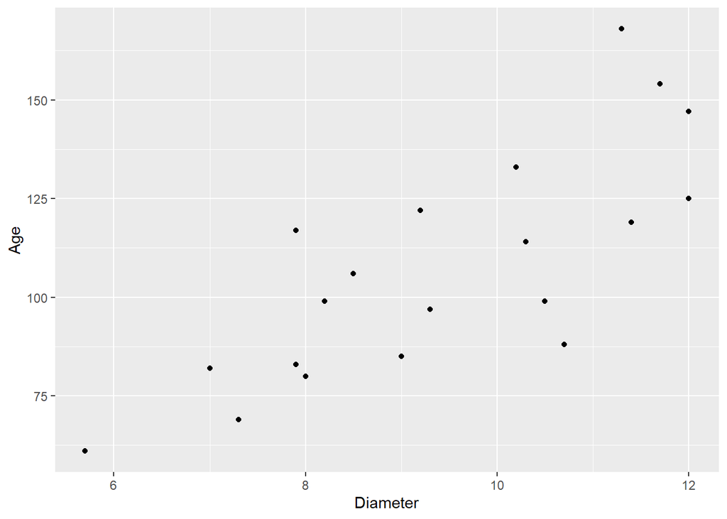

```r
library(ggplot2)
ggplot(data = tree, aes(x = Diameter, y = Age)) + geom_point()
```

## b.

**Estimate the population mean age of trees in the stand using ratio estimation and give an approximate standard error for your estimate**
$$e_i = y_i - \hat{B}x_i \\
\hat{V}(\hat{\bar{y}}) = (1 - \frac{n}{N})(\frac{\bar{x_U}}{\bar{x}})^2
\frac{s_e^2}{n}$$

```r
xbarU = 10.3
Bhat = mean(tree$Age) / mean(tree$Diameter)
ybar.ratio = Bhat * xbarU
ybar.ratio
```

```
## [1] 117.6204
```

```r
e.ratio = tree$Age -  Bhat * tree$Diameter

ybar.ratio.error = sqrt((1 - 20 / 1132) * (xbarU / mean(tree$Diameter))^2 * var(e.ratio) / 20)
ybar.ratio.error
```

```
## [1] 4.354872
```

## c.

** Repeat (b) using regression estimation. **

```r
bhat1 = cor(tree$Diameter, tree$Age) * sd(tree$Age)/sd(tree$Diameter)
bhat0 = mean(tree$Age) - bhat1 * mean(tree$Diameter)
ybar.reg = bhat0 + bhat1* xbarU
ybar.reg
```

```
## [1] 118.3634
```

```r
e.reg = tree$Age -  (bhat0 + bhat1 * tree$Diameter)

ybar.reg.error = sqrt((1 - 20 / 1132)  * var(e.reg) / 20)
ybar.reg.error
```

```
## [1] 3.9622
```

## d.

**Label your estimates on your graph. How do they compare?**

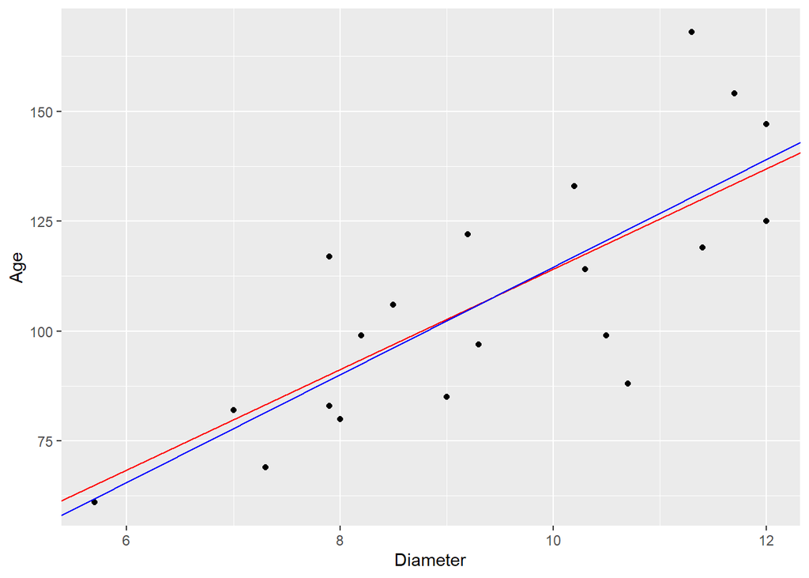

```r
ggplot(data = tree, aes(x = Diameter, y = Age)) + geom_point() + geom_abline(slope = Bhat, intecept = 0, color = "red") + geom_abline(slope = bhat1, intercept = bhat0, color = "blue")
```

The Ratio (red) and Regression (blue) estimates are very similar. Either one would make sense for this data.

# P3 Problem 11, Chapter 4, page 157

## a.

**Draw a histogram of the number of physicians for the 100 counties.**

```r
counties <- read.csv("counties.csv")
head(counties)
```

|  | RN | state | county | landarea | totpop | physician | enroll | percpub | civlabor | unemp | farmpop | numfarm | farmacre | fedgrant | fedciv | milit | veterans | percviet |
| --- | --- | --- | --- | --- | --- | --- | --- | --- | --- | --- | --- | --- | --- | --- | --- | --- | --- | --- |
| 1 | 27 | AL | Escambia | 948 | 36023 | 24 | 6931 | 95.4 | 15247 | 1339 | 531 | 414 | 90646 | 122.3 | 85 | 370 | 3723 | 27.1 |
| 2 | 48 | AL | Marshall | 567 | 73524 | 44 | 11928 | 98.6 | 38803 | 3189 | 1592 | 1582 | 136599 | 235.7 | 316 | 748 | 8510 | 29.1 |
| 3 | 85 | AK | Prince of Wales | 7325 | 6408 | 7 | 1317 | 98.6 | 2787 | 383 | 71 | 2 | 214 | 32.2 | 126 | 63 | 809 | 44.6 |
| 4 | 126 | AR | Cross | 616 | 19261 | 11 | 4066 | 99.1 | 8336 | 704 | 762 | 492 | 339830 | 81.4 | 87 | 107 | 1505 | 23.9 |
| 5 | 158 | AR | Newton | 823 | 7649 | 3 | 1579 | 99.2 | 3280 | 270 | 600 | 562 | 98106 | 31.7 | 71 | 44 | 807 | 25.5 |
| 6 | 186 | CA | Butte | 1640 | 188377 | 327 | 27899 | 94.5 | 77500 | 7303 | 2818 | 2030 | 494530 | 688.0 | 570 | 577 | 23958 | 27.6 |

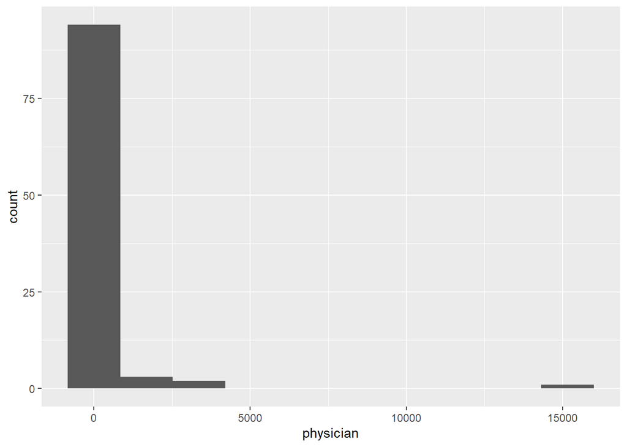

```r
ggplot(data = counties, aes(x = physician)) + geom_histogram(bins = 10)
```

## b.

** Estimate the total number of physicians in the United States, along with its standard error, using Ny¯.**

```r
# Total number of counties
N <- 3141
est.total <- mean(counties$physician) * N
est.total
```

```
## [1] 933411
```

```r
se.est.total <- N * sqrt((1 - 100/N) * var(counties$physician) / 100)
se.est.total
```

```
## [1] 491982.8
```

## c.

**Plot the number of physicians vs. population for each county. Which method do you think is more appropriate for these data: ratio estimation or regression estimation?**

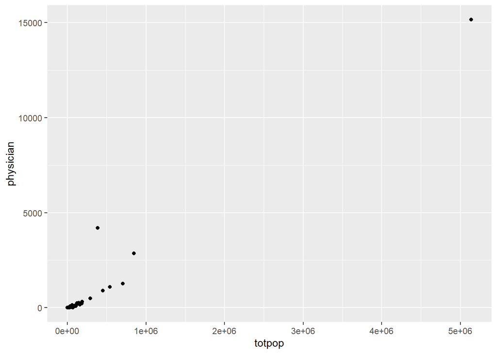

```r
ggplot(data = counties, aes(x = totpop, y = physician)) + geom_point()
```

```r
# Outlier, lets find it
which.max(counties$totpop)
```

```
## [1] 18
```

```r
counties[18,]
```

|  | RN | state | county | landarea | totpop | physician | enroll | percpub | civlabor | unemp | farmpop | numfarm | farmacre | fedgrant | fedciv | milit | veterans | percviet |
| --- | --- | --- | --- | --- | --- | --- | --- | --- | --- | --- | --- | --- | --- | --- | --- | --- | --- | --- |
| 18 | 606 | IL | Cook | 946 | 5139341 | 15153 | 853115 | 81.5 | 2715405 | 196796 | 196 | 389 | 46907 | 20151.2 | 61976 | 16480 | 457880 | 24.2 |

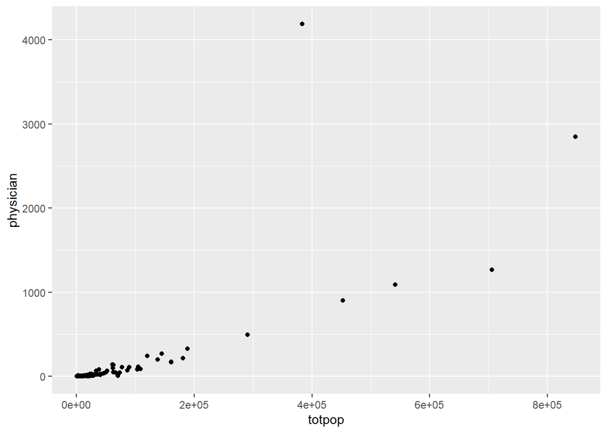

```r
# Cook county has really pop and physician count, we will plot without it
ggplot(data = counties[-18,], aes(x = totpop, y = physician)) + geom_point()
```

We can see (after removing the outlier) as the total population increases, the variablity in the number of physicians is also increasing, thus we should use ration estimation.

## d.

**Using the method you chose in (c), use the auxiliary variable population to estimate.the total number of physicians in the United States, along with the standard error**

```r
# We know the ratio of means is equal to the ratio of totals
bhat_phys <- mean(counties$physician) / mean(counties$totpop)
bhat_phys
```

```
## [1] 0.002507104
```

```r
tot.ratio <- bhat_phys * 255077536 # we use total population
tot.ratio
```

```
## [1] 639506
```

```r
e.tot <- counties$physician  - bhat_phys * counties$totpop

tot.ratio.se <- N * sqrt((1- 100/N) * (255077536 / (N/100 * sum(counties$totpop)))^2* var(e.tot)/100)
tot.ratio.se
```

```
## [1] 87885.27
```

## e.

**The “true” value for total number of physicians in the population is 532,638. Which method of estimation came closer?**

We can see that our ratio estimate came much closer to the true value for total number of physicians then our simple total estimation.

# P4 Problem 36, Ch 4, page 163

## a

** Generate 500 data sets, each with 30 pairs of observations (xi, yi). Use a bivariate normal distribution with means 0, standard deviations 1, and correlation 0.5 to generate each pair $(x_i, y_i)$. For each data set, calculate $\bar{y}$ and $\hat{\bar{y}}_{reg}$ y¯reg, using x¯U = 0.Graph a histogram of the 500 values of y¯ and another histogram of the 500 values of ˆy¯reg. What do you see? **

```r
library(survey)
```

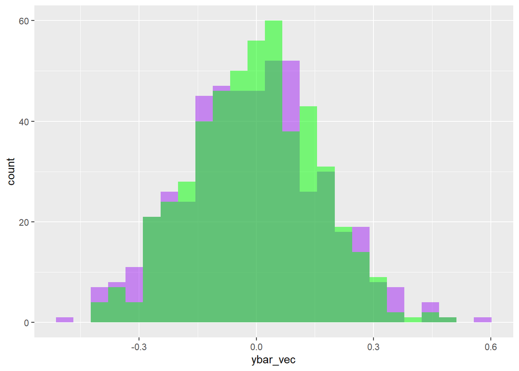

```r
library(MASS)
set.seed(123)

#Sample Size
n <- 30

#Sample from a multivariate normal with both means 0, both SDs 1, and 0.5 correlation
my_sample <- mvrnorm(n, mu=c(0,0), Sigma=matrix(c(1,0.5,0.5,1), nrow=2, ncol=2))

ybar_vec <- c()
yreg_vec <- c()
for (x in 1:500) {
  my_sample <- mvrnorm(n, mu=c(0,0), Sigma=matrix(c(1,0.5,0.5,1), nrow=2, ncol=2))
  ybar = mean(my_sample[,2])

  # regression estimate
  Bhat1 = cor(my_sample[,1], my_sample[,2]) * sd(my_sample[,2]) / sd(my_sample[,1])
  Bhat0 = mean(my_sample[,2]) - Bhat1 * mean(my_sample[,1])

  yreg = Bhat0 + Bhat1 * 0

  ybar_vec <- c(ybar_vec, ybar)
  yreg_vec <- c(yreg_vec, yreg)
}

ggplot() + aes(x = ybar_vec) + geom_histogram(fill = "purple", alpha = 0.5, bins = 25) + geom_histogram(aes(x = yreg_vec), fill = "green", alpha = 0.5, bins = 25)
```

From the plot, we can see $\hat{\bar{y}}_{reg}$ estimates the true population mean more often with less variablity than the standard $\bar{y}$ estimate.

## b

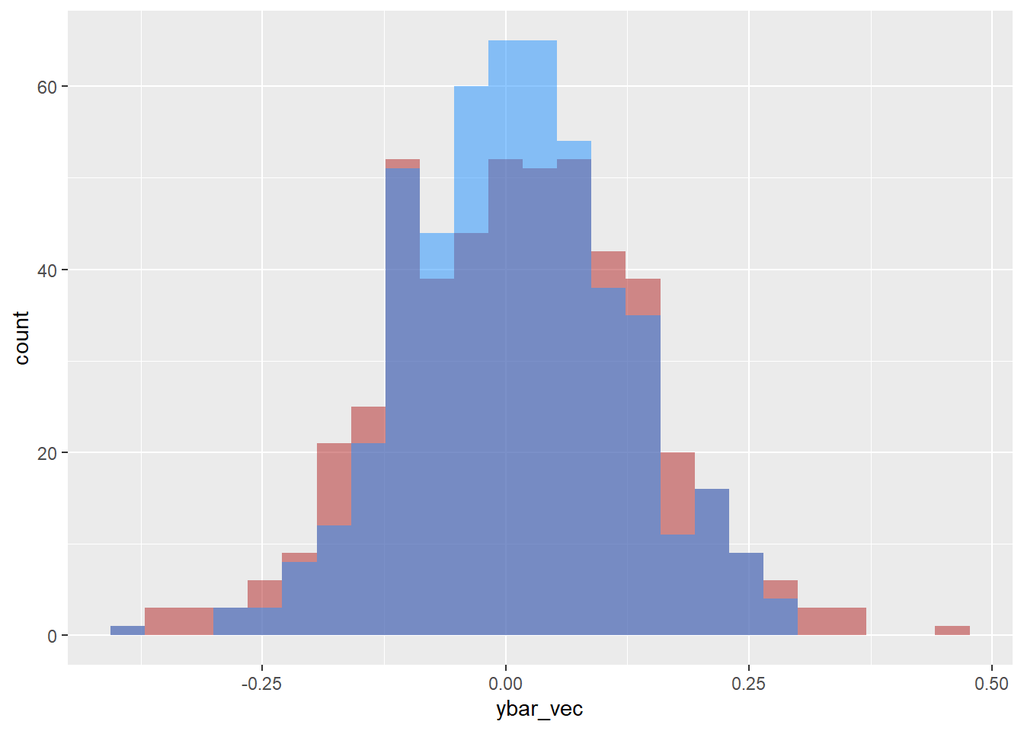

```r
#Sample Size
n1 <- 60

#Sample from a multivariate normal with both means 0, both SDs 1, and 0.5 correlation
#my_sample <- mvrnorm(n, mu=c(0,0), Sigma=matrix(c(1,0.5,0.5,1), nrow=2, ncol=2))

ybar_vec <- c()
yreg_vec <- c()
for (x in 1:500) {
  my_sample <- mvrnorm(n1, mu=c(0,0), Sigma=matrix(c(1,0.5,0.5,1), nrow=2, ncol=2))
  ybar = mean(my_sample[,2])

  # regression estimate
  Bhat1 = cor(my_sample[,1], my_sample[,2]) * sd(my_sample[,2]) / sd(my_sample[,1])
  Bhat0 = mean(my_sample[,2]) - Bhat1 * mean(my_sample[,1])

  yreg = Bhat0 + Bhat1 * 0

  ybar_vec <- c(ybar_vec, ybar)
  yreg_vec <- c(yreg_vec, yreg)
}

ggplot() + aes(x = ybar_vec) + geom_histogram(fill = "firebrick", alpha = 0.5, bins = 25) + geom_histogram(aes(x = yreg_vec), fill = "dodgerblue", alpha = 0.5, bins = 25)
```

In this plot, we can see now with double the sample size, the estimation of the true mean from the regression estimate is even more frequent with even less variability than the standard measure of the mean.